# P&S-2024: Final Project

Vladyslav Sydorak, Mykhailo Ponomarenko, Mykhailo Ivasiuk

```r
library(tidyr)
library(dplyr)
```

```r
library(ggplot2)
library(caTools)
data <- read.csv("socioeconomic_voting.csv")
colnames(data) <- c("State", "County", "FIPS", "Unemployment", "MedianIncome", "UrbanInfluenceCode", "IncomePercentile", "BachelorsPercentage", "WinningParty", "PercentageForDominantParty")
data
```

| State | County | FIPS | Unemployment | MedianIncome | UrbanInfluenceCode | IncomePercentile | BachelorsPercentage | WinningParty | PercentageForDominantParty |
| --- | --- | --- | --- | --- | --- | --- | --- | --- | --- |
| ALABAMA | AUTAUGA | 1001 | 5.3 | 66444 | 2 | 0.955223881 | 29.6 | REPUBLICAN | 71.43680 |
| ALABAMA | BALDWIN | 1003 | 6.1 | 65658 | 2 | 0.940298507 | 32.6 | REPUBLICAN | 76.17137 |
| ALABAMA | BARBOUR | 1005 | 7.7 | 38649 | 6 | 0.164179104 | 11.9 | REPUBLICAN | 53.45123 |
| ALABAMA | BIBB | 1007 | 7.3 | 48454 | 1 | 0.611940299 | 10.9 | REPUBLICAN | 78.42626 |
| ALABAMA | BLOUNT | 1009 | 4.5 | 56894 | 1 | 0.895522388 | 14.7 | REPUBLICAN | 89.57155 |
| ALABAMA | BULLOCK | 1011 | 6.0 | 32027 | 6 | 0.074626866 | 9.4 | DEMOCRAT | 74.70193 |
| ALABAMA | BUTLER | 1013 | 9.5 | 39442 | 6 | 0.194029851 | 13.0 | REPUBLICAN | 57.52530 |
| ALABAMA | CALHOUN | 1015 | 7.7 | 48166 | 2 | 0.597014925 | 19.2 | REPUBLICAN | 68.84844 |
| ALABAMA | CHAMBERS | 1017 | 7.4 | 45447 | 5 | 0.410447761 | 12.7 | REPUBLICAN | 57.26904 |
| ALABAMA | CHEROKEE | 1019 | 5.1 | 46365 | 6 | 0.507462687 | 14.6 | REPUBLICAN | 86.03366 |

[output cut: 3105 more lines]

So, in our dataset we have 10 columns, now we have to conduct our initial descriptive analysis of this data. First three columns contain pretty obvious data-information about the place which our dataset describes. Name of the state, of a county within it and FIPS-a unique code for each county. For all of the following columns we will draw a histogram to approximate their distribution and find a relationship between them.

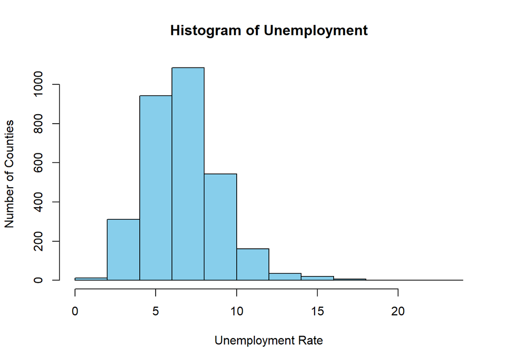

```r
hist(data$Unemployment, main = "Histogram of Unemployment",
     xlab = "Unemployment Rate", ylab = "Number of Counties",  col = "skyblue", border = "black")
```

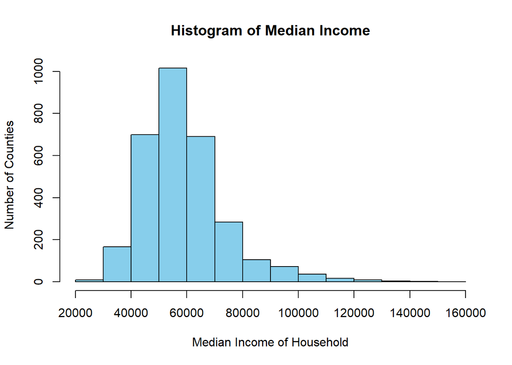

```r
hist(data$MedianIncome, main = "Histogram of Median Income",
     xlab = "Median Income of Household", ylab = "Number of Counties", col = "skyblue", border = "black")
```

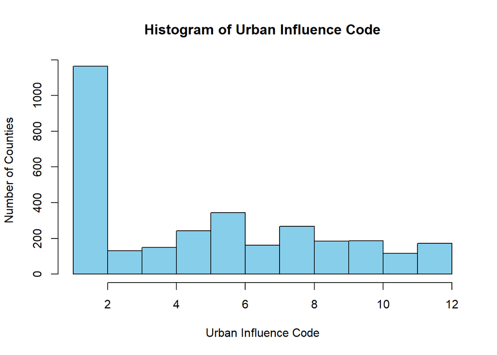

```r
hist(data$UrbanInfluenceCode, main = "Histogram of Urban Influence Code",
     xlab = "Urban Influence Code", ylab = "Number of Counties", col = "skyblue", border = "black")
```

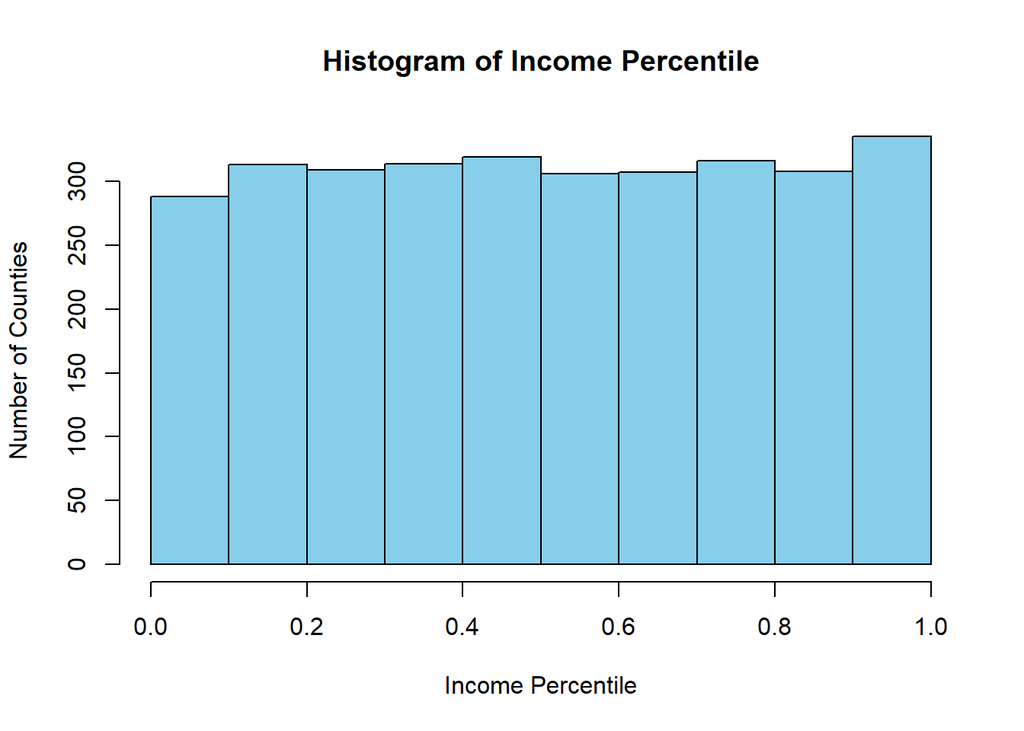

```r
hist(data$IncomePercentile, main = "Histogram of Income Percentile",
     xlab = "Income Percentile", ylab = "Number of Counties", col = "skyblue", border = "black")
```

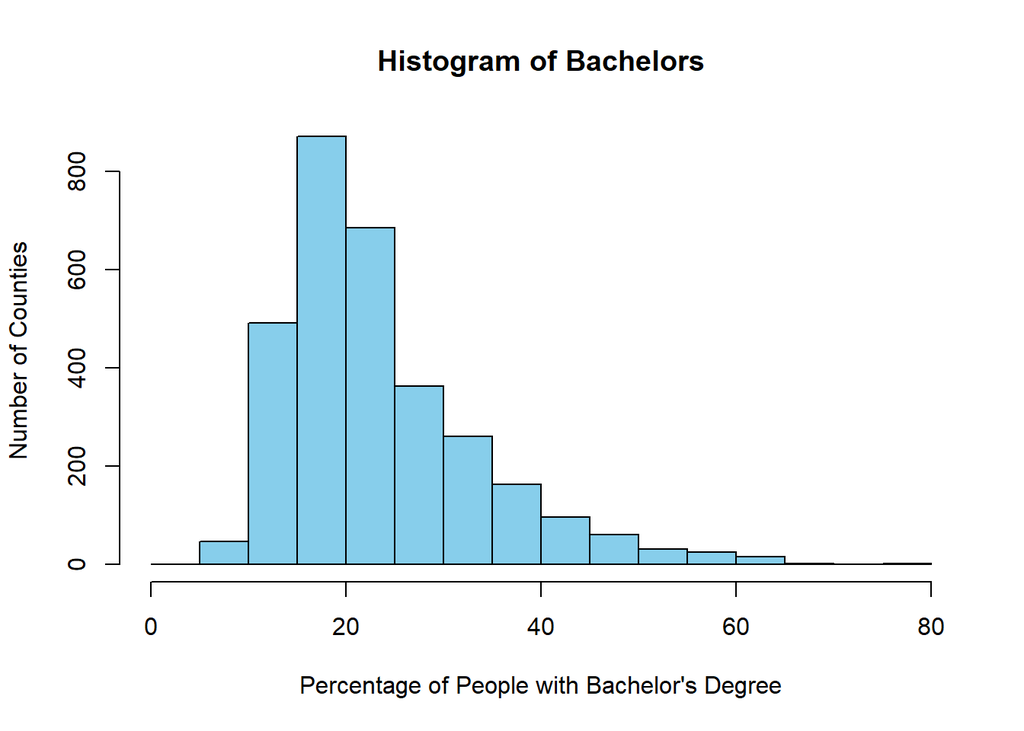

```r
hist(data$BachelorsPercentage, main = "Histogram of Bachelors",
     xlab = "Percentage of People with Bachelor's Degree", ylab = "Number of Counties", col = "skyblue", border = "black")
```

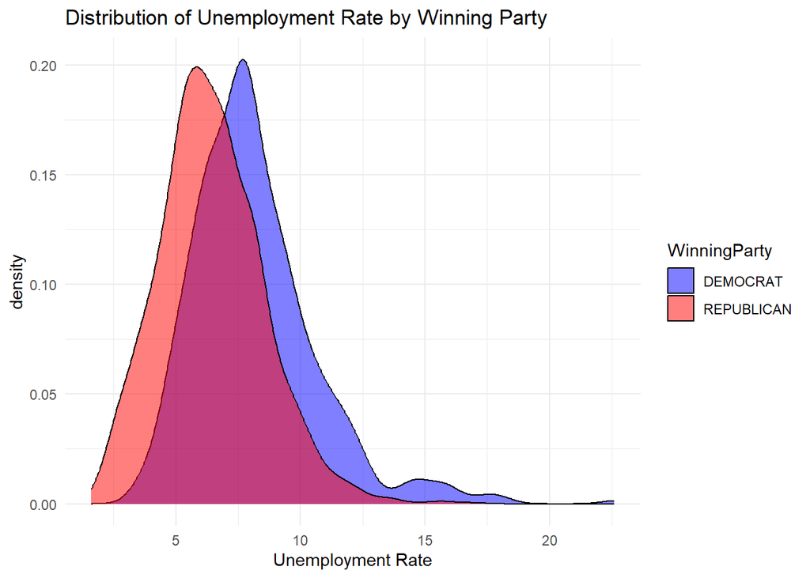

```r
ggplot(data, aes(x = Unemployment, fill = WinningParty)) +
  geom_density(alpha = 0.5) +
  xlab("Unemployment Rate") +
  ggtitle("Distribution of Unemployment Rate by Winning Party") +
  scale_fill_manual(values = c("REPUBLICAN" = "red", "DEMOCRAT" = "blue")) +
  theme_minimal()
```

There is significant overlap between the two curves, indicating that unemployment rate alone does not perfectly distinguish Democrat vs Republican counties.

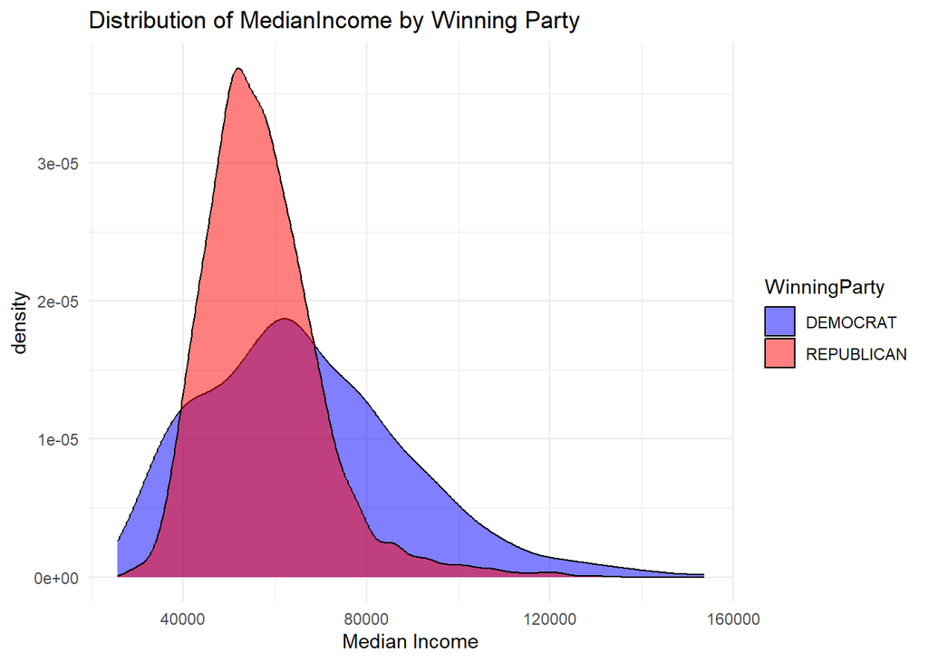

```r
ggplot(data, aes(x = MedianIncome, fill = WinningParty)) +
  geom_density(alpha = 0.5) +
  xlab("Median Income") +
  ggtitle("Distribution of MedianIncome by Winning Party") +
  scale_fill_manual(values = c("REPUBLICAN" = "red", "DEMOCRAT" = "blue")) +
  theme_minimal()
```

The Republican curve peaks at a lower median income (around $40,000–$50,000). The Democratic curve peaks at a slightly higher median income (around $50,000–$65,000).

Also note: Republican counties have a narrower distribution, with most counties concentrated in the $40,000–$60,000 income range. There is very little representation above $80,000.

Democrat counties have a wider distribution. While many are in the $50,000–$60,000 range, there is a significant number of counties with median incomes well above $80,000

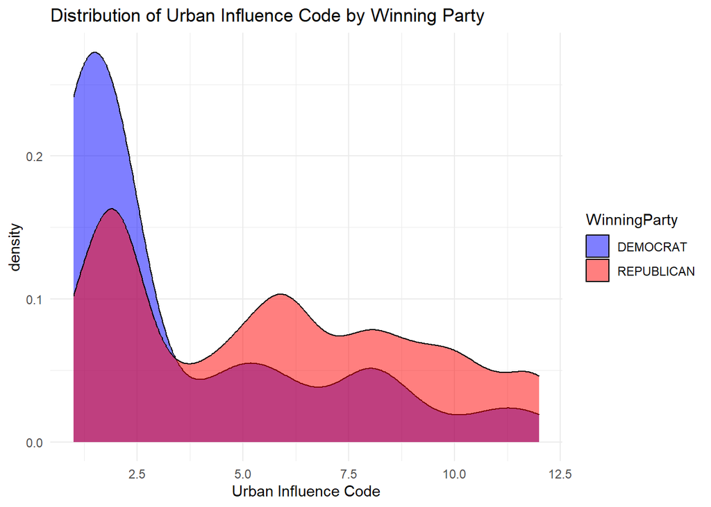

```r
ggplot(data, aes(x = UrbanInfluenceCode, fill = WinningParty)) +
  geom_density(alpha = 0.5) +
  xlab("Urban Influence Code") +
  ggtitle("Distribution of Urban Influence Code by Winning Party") +
  scale_fill_manual(values = c("REPUBLICAN" = "red", "DEMOCRAT" = "blue")) +
  theme_minimal()
```

The Democratic curve is highest for lower values of Urban Influence Code (around 1-2) indicating highly urban areas.

For very high Urban Influence Code, the distributions are similar, but Republicans retain a slight density.

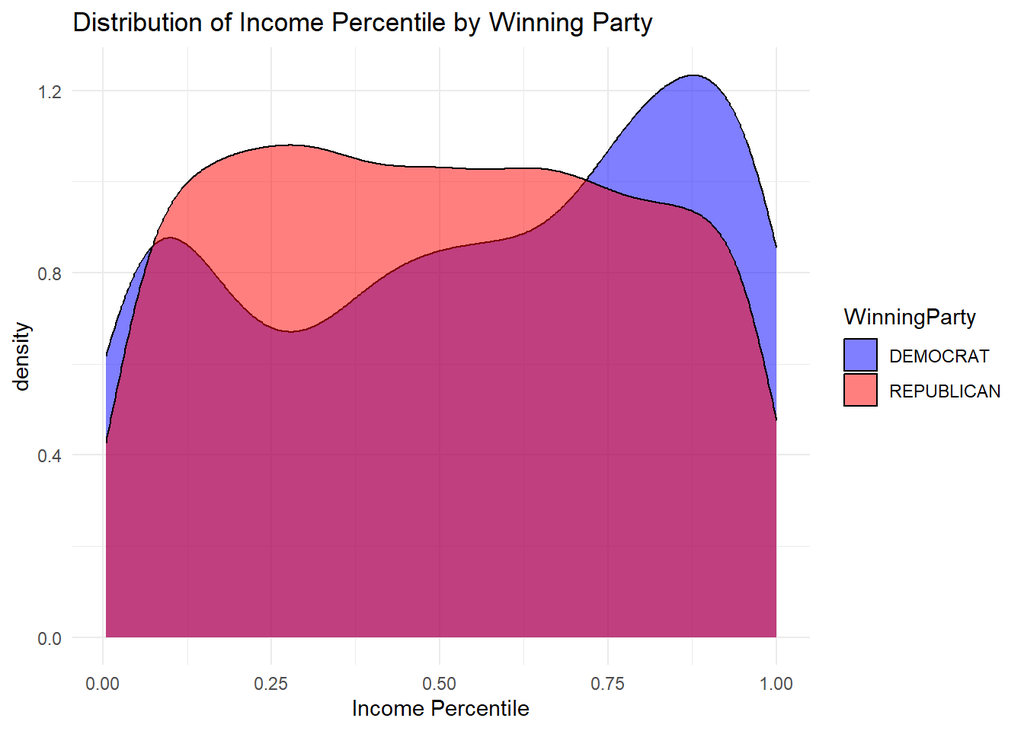

```r
ggplot(data, aes(x = IncomePercentile, fill = WinningParty)) +
  geom_density(alpha = 0.5) +
  xlab("Income Percentile") +
  ggtitle("Distribution of Income Percentile by Winning Party") +
  scale_fill_manual(values = c("REPUBLICAN" = "red", "DEMOCRAT" = "blue")) +
  theme_minimal()
```

The Democratic curve has two peaks, indicating a small distribution around lowest-income and a noticeable peak in the higher income percentiles. Concentration in higher-income groups.

The Republican curve has a very strong density at lower to mid-income percentiles. Significant levels of middle-income.

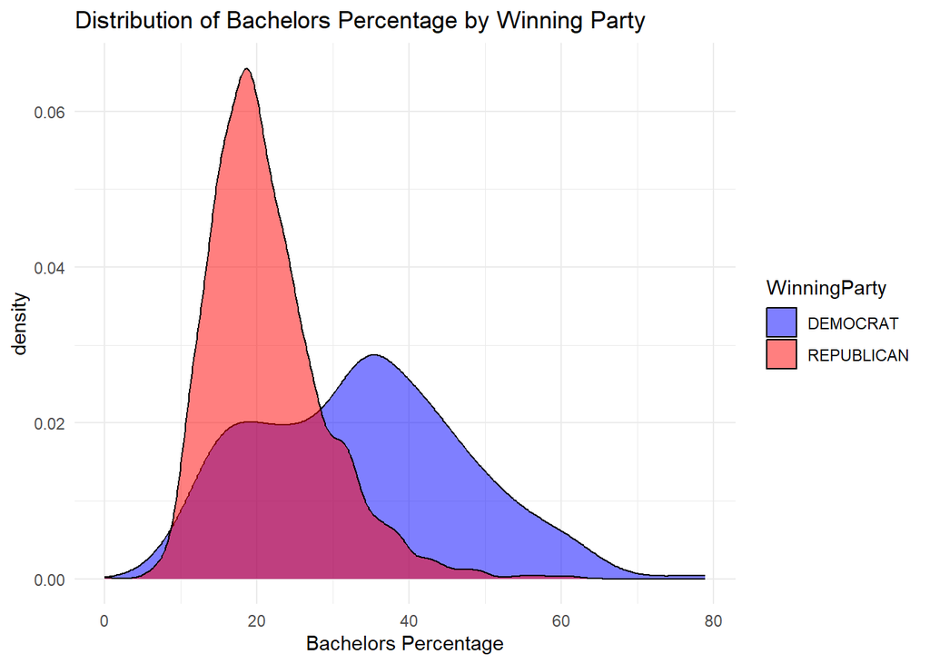

```r
ggplot(data, aes(x = BachelorsPercentage, fill = WinningParty)) +
  geom_density(alpha = 0.5) +
  xlab("Bachelors Percentage") +
  ggtitle("Distribution of Bachelors Percentage by Winning Party") +
  scale_fill_manual(values = c("REPUBLICAN" = "red", "DEMOCRAT" = "blue")) +
  theme_minimal()
```

The Republican curve shows the distribution peaks at lower levels of bachelor’s degree percentages, around 20%. The density decreases significantly beyond 20%, indicating small levels of high education.

The Democratic curve has a peak at higher levels of education (around 30-40%), also in contrast to Republicans, Democrats maintain density at bachelor’s percentages around 50-60%.

Overlap in the low-mid range, indicates moderate low-mid level of education for both party’s.

### Hypotheses Testing

The Chi-Squared test is used to determine if there is a significant difference between observed and expected frequencies. The test statistic is given by:

$$\chi^2 = \sum_{i=1}^k \frac{(O_i - E_i)^2}{E_i}$$

where:

- $O_i$ = observed frequency for category $i$,
- $E_i$ = expected frequency for category $i$,
- $k$ = number of categories.

This statistic follows a Chi-Squared distribution with $k-1$ degrees of freedom.

*Interpreting the Result*

To determine whether the result is statistically significant, we compare the test statistic ($\chi^2$) to the critical value of the Chi-Squared distribution at the chosen significance level ($\alpha$):

- Find the critical value, $\chi^2_{\text{critical}}$, from a Chi-Squared distribution table with $k-1$ degrees of freedom.
- If $\chi^2 > \chi^2_{\text{critical}}$, reject the null hypothesis $H_0$.

Alternatively, calculate the p-value:

- The p-value is the probability of observing a test statistic at least as extreme as the calculated $\chi^2$, assuming $H_0$ is true.
- Use statistical software or a Chi-Squared distribution table to find the p-value.
- If the p-value is less than $\alpha$, reject the null hypothesis $H_0$.

*Conclusion*

Based on the comparison:

- If $\chi^2 > \chi^2_{\text{critical}}$ or $\text{p-value} < \alpha$, conclude that there is a significant difference.
- Otherwise, fail to reject $H_0$, indicating no significant difference.

*Testing*

Now let’s check how different factors affect the outcome of the election.

```r
data$WinningParty <- ifelse(data$WinningParty == "DEMOCRAT", 1, 0)
```

```r
neyman_pearson <- function(list) {
   democratic <- c()
   republican <- c()
   values <- unique(list)
   for (i in 1:length(values)) {
     democratic[i] = 0
     republican[i] = 0
   }
   for (i in 1:nrow(data)) {
     num <- which(values == list[i])
     if (data$WinningParty[i] == 1) {
       democratic[num] <- democratic[num] + 1
     }
     else {
       republican[num] <- republican[num] + 1
     }

   }
   df <- data.frame(democratic, republican)
   return(df)
}
print("Unemployment")
```

```
## [1] "Unemployment"
```

```r
chisq.test(neyman_pearson(data$Unemployment))
```

```
##
##  Pearson's Chi-squared test
##
## data:  neyman_pearson(data$Unemployment)
## X-squared = 425.56, df = 140, p-value < 2.2e-16
```

```r
print("Median Income")
```

```
## [1] "Median Income"
```

```r
chisq.test(neyman_pearson(data$MedianIncome))
```

```
##
##  Pearson's Chi-squared test
##
## data:  neyman_pearson(data$MedianIncome)
## X-squared = 3066.6, df = 3013, p-value = 0.2436
```

```r
print("Urban Influence Code")
```

```
## [1] "Urban Influence Code"
```

```r
chisq.test(neyman_pearson(data$UrbanInfluenceCode))
```

```
##
##  Pearson's Chi-squared test
##
## data:  neyman_pearson(data$UrbanInfluenceCode)
## X-squared = 284.55, df = 11, p-value < 2.2e-16
```

```r
print("Bachelors Percentage")
```

```
## [1] "Bachelors Percentage"
```

```r
chisq.test(neyman_pearson(data$BachelorsPercentage))
```

```
##
##  Pearson's Chi-squared test
##
## data:  neyman_pearson(data$BachelorsPercentage)
## X-squared = 1323.3, df = 460, p-value < 2.2e-16
```

### Naive Bayes

A Naive Bayes Classifier is a simple algorithm based on Bayes’ theorem, commonly used for solving classification problems. In this context, a classification problem involves determining whether a given observation of parameters (e.g., UnemploymentRate, MedianIncome, etc.) should be classified as Democratic or Republican.

It is a **probabilistic classifier**, which means it predicts based on the probability of an observation belonging to each class. To compute it, this algorithm uses **Bayes’ formula,**:

$$\mathsf{P}(\mathrm{class}\mid
\mathrm{observation})=\frac{\mathsf{P}(\mathrm{observation}\mid\mathrm{class})\mathsf{P}(\mathrm{class})}{\mathsf{P}(\mathrm{observation})}$$

In our case we have two classes: Democratic and Republican

Under the strong **independence** assumption, one can calculate $\mathsf{P}(\mathrm{observation} \mid \mathrm{class})$ as
$$\mathsf{P}(\mathrm{observation}) =
\prod_{i=1}^{n} \mathsf{P}(\mathrm{feature}_i), \qquad
\mathsf{P}(\mathrm{observation} \mid \mathrm{class}) = \prod_{i=1}^{n}
\mathsf{P}(\mathrm{feature}_i \mid \mathrm{class}),$$
where $n$ is the total number of features describing a given observation

Thus, $\mathsf{P}(\mathrm{class}|\mathrm{observation})$ now can be calculated as

$$\mathsf{P}(\mathrm{class} \mid
\mathrm{\mathrm{observation}}) = \mathsf{P}(\mathrm{class})\times
\prod_{i=1}^{n}\frac{\mathsf{P}(\mathrm{feature}_i\mid
\mathrm{class})}{\mathsf{P}(\mathrm{feature}_i)}\tag{1}$$

Now let’s make a Naive Bayes estimator which given Unemployment rate, Median income, Urban Influence code, Income percentile and percentage of people with Bachelor’s degree will determine the dominant party for a given county

```r
split <- sample.split(data$WinningParty, SplitRatio = 0.7)
train_data <- subset(data, split == TRUE)
test_data <- subset(data, split == FALSE)
```

```r
naive_bayes <- function(unemployment, median, uic, percentile, bachelors, train_data) {
  total_count <- nrow(train_data)
  dem_count <- sum(train_data$WinningParty == 1)
  rep_count <- sum(train_data$WinningParty == 0)

  dem_prob <- dem_count / total_count
  rep_prob <- rep_count / total_count


  dem_prob <- dem_prob * mean(train_data$Unemployment[train_data$WinningParty == 1] == unemployment)
  rep_prob <- rep_prob * mean(train_data$Unemployment[train_data$WinningParty == 0] == unemployment)

  dem_prob <- dem_prob * mean(train_data$MedianIncome[train_data$WinningParty == 1] == median)
  rep_prob <- rep_prob * mean(train_data$MedianIncome[train_data$WinningParty == 0] == median)

  dem_prob <- dem_prob * mean(train_data$UrbanInfluenceCode[train_data$WinningParty == 1] == uic)
  rep_prob <- rep_prob * mean(train_data$UrbanInfluenceCode[train_data$WinningParty == 0] == uic)

  dem_prob <- dem_prob * mean(train_data$IncomePercentile[train_data$WinningParty == 1] == percentile)
  rep_prob <- rep_prob * mean(train_data$IncomePercentile[train_data$WinningParty == 0] == percentile)

  dem_prob <- dem_prob * mean(train_data$BachelorsPercentage[train_data$WinningParty == 1] == bachelors)
  rep_prob <- rep_prob * mean(train_data$BachelorsPercentage[train_data$WinningParty == 0] == bachelors)

  if (dem_prob > rep_prob) {
    return(1)
  } else {
    return(0)
  }
}
```

```r
counter <- 0
for (i in 1:nrow(test_data)) {
  predicted_party <- naive_bayes(test_data$Unemployment[i],
                                 test_data$MedianIncome[i],
                                 test_data$UrbanInfluenceCode[i],
                                 test_data$IncomePercentile[i],
                                 test_data$BachelorsPercentage[i],
                                 train_data)
  if (predicted_party == test_data$WinningParty[i]) {
    counter <- counter + 1
  }
}

accuracy <- counter / nrow(test_data)
cat("Accuracy:", accuracy, "\n")
```

```
## Accuracy: 0.8245989
```

### Logistic Regression

The linear probability model (LPM) is a simple approach to modeling binary outcomes, but it has notable disadvantages:

- Fitted probabilities can fall outside the range $[0, 1]$.
- The partial effect of any explanatory variable is constant.

To overcome these limitations, we use more sophisticated binary response models such as the **logit** model. This model ensures that probabilities are always between 0 and 1, providing a better theoretical foundation.

*Response Probability*

In a binary response model, the primary interest lies in the response probability:
$$P(y = 1 | x) = P(y = 1 | x_1, x_2, \dots, x_k),$$

where $y$ is the dependent variable (in our case $WinningParty$) and $x_1, x_2, \dots, x_k$ represent explanatory variables (e.g., $MedianIncome$, $UnemploymentRate$, etc.).

*Specifying the Logit Model*

Logistic regression models the relationship between a binary dependent variable $Y$ and a set of predictors $X_1, X_2, \dots, X_k$. The dependent variable $Y$ takes values:
$$Y =
\begin{cases}
1 & \text{(Event occurs, e.g., Democrat wins)} \\
0 & \text{(Event does not occur, e.g., Republican wins)}
\end{cases}$$

The logit model assumes that the log-odds (odds compare the probability of an event happening (P) to the probability of it not happening $\frac{P}{1-P}$) of the probability $P(Y=1 | X)$ follows a specific functional form to ensure values are strictly between 0 and 1:
$$P(y = 1 | x) = G(\beta_0 + \beta_1 x_1 + \dots + \beta_k x_k),$$
where:
$$G(z) = \frac{\exp(z)}{1 + \exp(z)}.$$
This logistic function $G(z)$ is the **cumulative distribution function (CDF)** of a standard logistic random variable. It has the following properties:

- $0 < G(z) < 1$ for all real $z$,
- $G(z) \to 0$ as $z \to -\infty$,
- $G(z) \to 1$ as $z \to +\infty$.

The logit model is widely used because it provides a flexible and interpretable way to model probabilities.

*Estimation Using Maximum Likelihood*

The logit model is estimated using **Maximum Likelihood Estimation (MLE)**. Assume a random sample of size $n$. The likelihood function for $n$ observations is:
$$L(\beta) = \prod_{i=1}^n \left[ G(x_i \beta)^{y_i} \cdot \left(1 - G(x_i
\beta)\right)^{1 - y_i} \right],$$

Taking the natural logarithm of the likelihood gives the **log-likelihood function**:
$$\ell(\beta) = \sum_{i=1}^n \left[ y_i \log G(x_i \beta) + (1 - y_i) \log
(1 - G(x_i \beta)) \right].$$

The MLE of $\beta$, denoted $\hat{\beta}$, maximizes the log-likelihood $\ell(\beta)$.

*Advantages of the Logit Model*

- Probabilities are bounded between 0 and 1.
- The relationship between predictors and the probability of the outcome is nonlinear, allowing for more flexibility.
- Coefficients can be interpreted as the effect on the log-odds (odds compare the probability of an event happening (P) to the probability of it not happening $\frac{P}{1-P}$) of the outcome.

```r
logit_model <- glm(WinningParty ~ Unemployment + MedianIncome +
                   UrbanInfluenceCode + IncomePercentile + BachelorsPercentage,
                   data = train_data, family = binomial)

summary(logit_model)
```

```
##
## Call:
## glm(formula = WinningParty ~ Unemployment + MedianIncome + UrbanInfluenceCode +
##     IncomePercentile + BachelorsPercentage, family = binomial,
##     data = train_data)
##
## Coefficients:
##                       Estimate Std. Error z value Pr(>|z|)
## (Intercept)         -6.635e+00  5.397e-01 -12.292  < 2e-16 ***
## Unemployment         4.641e-01  3.805e-02  12.199  < 2e-16 ***
## MedianIncome        -3.078e-05  8.219e-06  -3.745  0.00018 ***
## UrbanInfluenceCode  -1.564e-01  2.814e-02  -5.558 2.74e-08 ***
## IncomePercentile    -2.190e+00  4.227e-01  -5.181 2.21e-07 ***
## BachelorsPercentage  2.029e-01  1.225e-02  16.563  < 2e-16 ***
## ---
## Signif. codes:  0 '***' 0.001 '**' 0.01 '*' 0.05 '.' 0.1 ' ' 1
##
## (Dispersion parameter for binomial family taken to be 1)
##
##     Null deviance: 2023.4  on 2179  degrees of freedom
## Residual deviance: 1213.3  on 2174  degrees of freedom
## AIC: 1225.3
##
## Number of Fisher Scoring iterations: 6
```

```r
test_data$predicted_prob <- predict(logit_model, newdata = test_data, type = "response")

test_data$predicted_party <- ifelse(test_data$predicted_prob > 0.5, 1, 0)

confusion_matrix <- table(test_data$WinningParty, test_data$predicted_party)
print(confusion_matrix)
```

```
##
##       0   1
##   0 739  32
##   1  81  83
```

```r
accuracy <- sum(diag(confusion_matrix)) / sum(confusion_matrix)
cat("Accuracy:", accuracy, "\n")
```

```
## Accuracy: 0.8791444
```

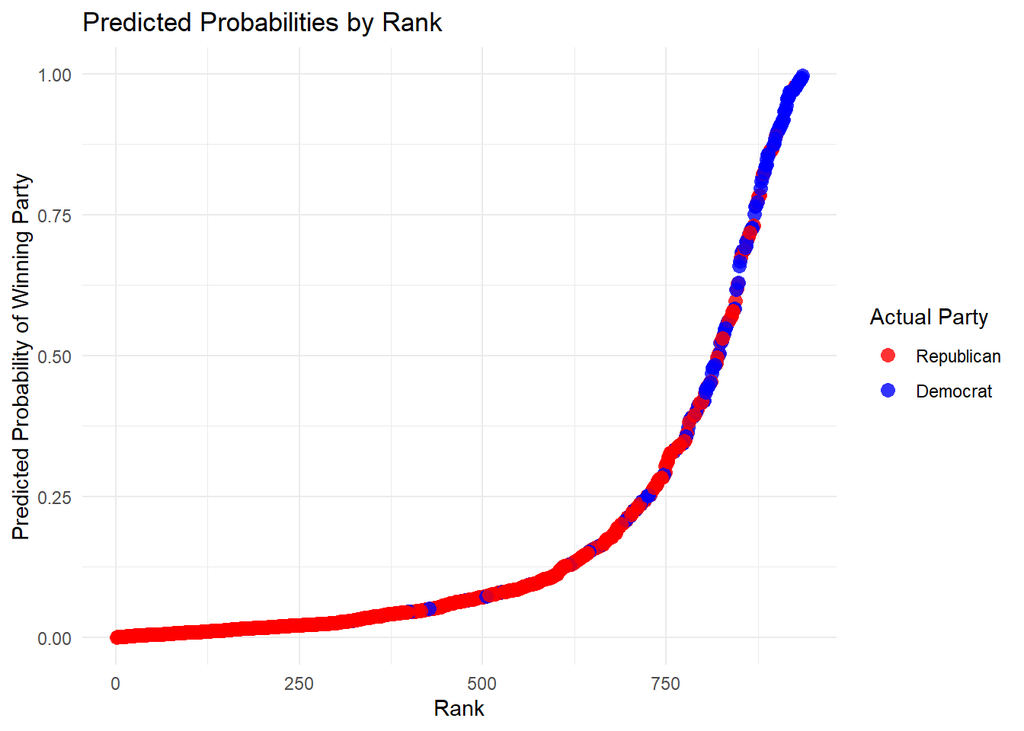

```r
test_data$rank <- rank(test_data$predicted_prob)

ggplot(test_data, aes(x = rank, y = predicted_prob)) +
  geom_point(aes(color = as.factor(WinningParty)), alpha = .8, shape = 16, size = 3) +
  xlab("Rank") +
  ylab("Predicted Probability of Winning Party") +
  ggtitle("Predicted Probabilities by Rank") +
  theme_minimal() +
  scale_color_manual(values = c("red", "blue"),
                     name = "Actual Party",
                     labels = c("Republican", "Democrat"))
```

*Conclusion*

The logit model is a powerful tool for modeling binary outcomes, overcoming the limitations of the LPM while providing interpretable results.